# TP6 - Modelos lineales

En este trabajo vamos a poner en práctica los conceptos aprendidos sobre regresión lineal, regresión múltiple e inferencia.

```r
# install.packages("tidyverse")
library(tidyverse)
```

## 1 - Regresión lineal

Utilizando el dataset `starbucks` del paquete *{openintro}*, ajuste un modelo lineal para estimar las calorías de un producto `calories` utilizando como predictor los gramos de grasa `fat`.

Visualice los resultados y escribir la ecuación del modelo.

Visualice los residuos.

Estime las calorías de un nuevo producto con **19 gramos de grasa**.

¿Qué pasa cuando hay 0 gramos de grasa?

¿Cómo varía la pendiente si ajustamos el mismo modelos pero utilizando `carb`, `fiber` o `protein`?

Volvamos al modelo con `fat`. si vemos la salida de `summary()`, ¿Qué puede decir del $R^2$ y del $p$?

Agreguede a uno cada uno de estos outliers y estude cómo afectan a la pendiente.

- Outlier 1: `fat=25, calories=150`
- Outlier 2: `fat=50, calories=150`
- Outlier 3: `fat=50, calories=700`

```r
# Ajuste
library(openintro)
model_starbucks <- starbucks %>%
  lm(calories ~ fat, .)
model_starbucks
```

```
#>
#> Call:
#> lm(formula = calories ~ fat, data = .)
#>
#> Coefficients:
#> (Intercept)          fat
#>      183.73        11.27
```

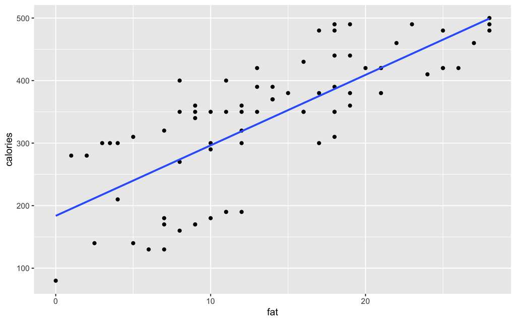

```r
starbucks %>% ggplot(aes(x = fat,
                         y = calories)) +
  geom_point() +
  geom_smooth(method = lm, se = FALSE)
```

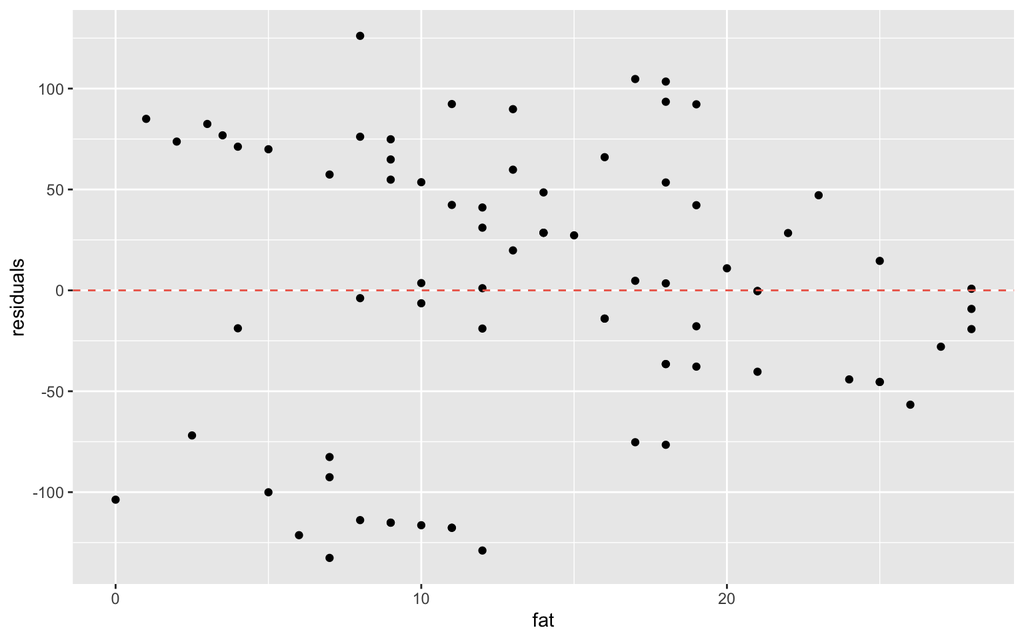

```r
# Residuos
cbind(starbucks, resid(model_starbucks)) %>%
  rename("residuals" = "resid(model_starbucks)") %>%
  ggplot(aes(x = fat,
             y = residuals)) +
  geom_point() +
  geom_hline(yintercept = 0, color= "#ED6A5A", linetype = "dashed")
```

```r
# Prediccion
predict.lm(model_starbucks, tibble(fat = 19))
```

```
#>        1
#> 397.7975
```

```r
predict.lm(model_starbucks, tibble(fat = 0))
```

```
#>        1
#> 183.7338
```

```r
# Modelos alternativos
model_starbucks_carb <- starbucks %>%
  lm(calories ~ carb, .)
model_starbucks_carb
```

```
#>
#> Call:
#> lm(formula = calories ~ carb, data = .)
#>
#> Coefficients:
#> (Intercept)         carb
#>     146.020        4.297
```

```r
model_starbucks_protein <- starbucks %>%
  lm(calories ~ protein, .)
model_starbucks_protein
```

```
#>
#> Call:
#> lm(formula = calories ~ protein, data = .)
#>
#> Coefficients:
#> (Intercept)      protein
#>     288.090        5.352
```

```r
model_starbucks_fiber <- starbucks %>%
  lm(calories ~ fiber, .)
model_starbucks_fiber
```

```
#>
#> Call:
#> lm(formula = calories ~ fiber, data = .)
#>
#> Coefficients:
#> (Intercept)        fiber
#>         310           13
```

```r
# Summary
summary(model_starbucks)
```

```
#>
#> Call:
#> lm(formula = calories ~ fat, data = .)
#>
#> Residuals:
#>      Min       1Q   Median       3Q      Max
#> -132.599  -44.130    3.469   54.868  126.134
#>
#> Coefficients:
#>             Estimate Std. Error t value Pr(>|t|)
#> (Intercept)  183.734     17.277   10.63  < 2e-16 ***
#> fat           11.267      1.117   10.09 1.32e-15 ***
#> ---
#> Signif. codes:  0 '***' 0.001 '**' 0.01 '*' 0.05 '.' 0.1 ' ' 1
#>
#> Residual standard error: 69.1 on 75 degrees of freedom
#> Multiple R-squared:  0.5756, Adjusted R-squared:  0.5699
#> F-statistic: 101.7 on 1 and 75 DF,  p-value: 1.32e-15
```

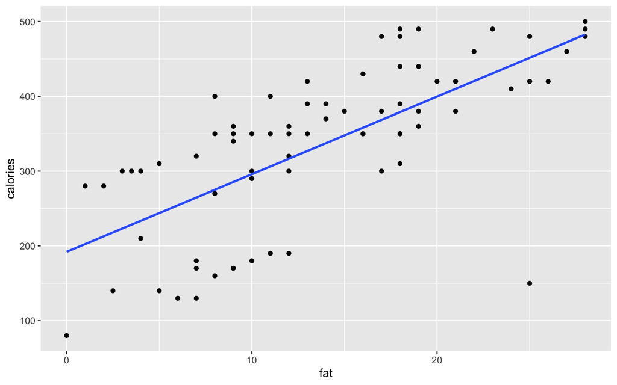

```r
# Outliers
starbucks_out1 <- starbucks %>%
  dplyr::select(c("calories", "fat")) %>%
  rbind(tibble(fat = 25, calories = 150))

starbucks_out1 %>%
  ggplot(aes(x = fat,
             y = calories)) +
  geom_point() +
  geom_smooth(method = lm, se = FALSE)
```

```r
model_starbucks_out1 <- starbucks_out1 %>%
  lm(calories ~ fat, .)
model_starbucks_out1
```

```
#>
#> Call:
#> lm(formula = calories ~ fat, data = .)
#>
#> Coefficients:
#> (Intercept)          fat
#>      192.00        10.38
```

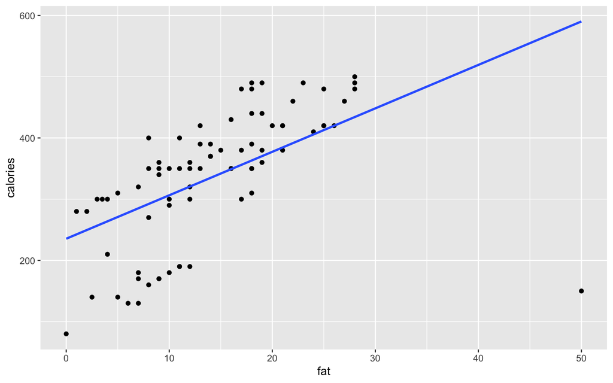

```r
starbucks_out2 <- starbucks %>%
  dplyr::select(c("calories", "fat")) %>%
  rbind(tibble(fat = 50, calories = 150))

starbucks_out2 %>%
  ggplot(aes(x = fat,
             y = calories)) +
  geom_point() +
  geom_smooth(method = lm, se = FALSE)
```

```r
model_starbucks_out2 <- starbucks_out2 %>%
  lm(calories ~ fat, .)
model_starbucks_out2
```

```
#>
#> Call:
#> lm(formula = calories ~ fat, data = .)
#>
#> Coefficients:
#> (Intercept)          fat
#>     235.411        7.097
```

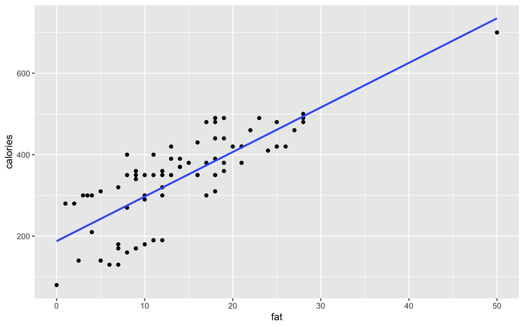

```r
starbucks_out3 <- starbucks %>%
  dplyr::select(c("calories", "fat")) %>%
  rbind(tibble(fat = 50, calories = 700))

starbucks_out3 %>%
  ggplot(aes(x = fat,
             y = calories)) +
  geom_point() +
  geom_smooth(method = lm, se = FALSE)
```

```r
model_starbucks_out3 <- starbucks_out3 %>%
  lm(calories ~ fat, .)
model_starbucks_out3
```

```
#>
#> Call:
#> lm(formula = calories ~ fat, data = .)
#>
#> Coefficients:
#> (Intercept)          fat
#>      187.81        10.94
```

## 2 - Regesión multiple

Utilizando el dataset `penguins`del paquete *{palmerpenguins}*, ajuste un modelo lineal para estimar el peso de los pinguinos (en g) `body_mass_g` a partir de la variable continua ancho de pico (en mm) `bill_depth_mm` y la variable discreta especie `species`,sin interacción.

Escriba la ecuación y estime el peso de un pinguino **Chinstrap** de ancho de pico **18 mm**.

Más allá de los parámetros ¿Qué puede decir del efecto conjunto de la variable discreta `species`?

Agerguemos la interacción al modelo ¿Es significativamente más “explicativo”? Volvamos a escribir la ecuación y a estimar el peso para un pinguino **Chinstrap** de ancho de pico **18 mm**.

```r
library(palmerpenguins)

# Modelo
model_penguins <- penguins %>%
  drop_na() %>%
  lm(body_mass_g ~ bill_depth_mm + species, .)

summary(model_penguins)
```

```
#>
#> Call:
#> lm(formula = body_mass_g ~ bill_depth_mm + species, data = .)
#>
#> Residuals:
#>     Min      1Q  Median      3Q     Max
#> -846.01 -261.75  -30.43  232.36 1185.55
#>
#> Coefficients:
#>                   Estimate Std. Error t value Pr(>|t|)
#> (Intercept)      -1000.846    324.968  -3.080  0.00225 **
#> bill_depth_mm      256.551     17.637  14.546  < 2e-16 ***
#> speciesChinstrap     8.111     52.874   0.153  0.87817
#> speciesGentoo     2245.878     73.956  30.368  < 2e-16 ***
#> ---
#> Signif. codes:  0 '***' 0.001 '**' 0.01 '*' 0.05 '.' 0.1 ' ' 1
#>
#> Residual standard error: 360 on 329 degrees of freedom
#> Multiple R-squared:  0.8019, Adjusted R-squared:  0.8001
#> F-statistic: 443.9 on 3 and 329 DF,  p-value: < 2.2e-16
```

```r
predict.lm(model_penguins, tibble(bill_depth_mm = 18, species = "Chinstrap"))
```

```
#>        1
#> 3625.186
```

```r
# Peso = -1000.846 + 256.551 * bill_depth_mm + 8.111 * speciesChinstrap + 2245.878 * speciesGentoo

library(car)
Anova(model_penguins, type = 3)
```

```
#> Anova Table (Type III tests)
#>
#> Response: body_mass_g
#>                  Sum Sq  Df  F value    Pr(>F)
#> (Intercept)     1229481   1   9.4853  0.002246 **
#> bill_depth_mm  27424833   1 211.5805 < 2.2e-16 ***
#> species       124655460   2 480.8538 < 2.2e-16 ***
#> Residuals      42644614 329
#> ---
#> Signif. codes:  0 '***' 0.001 '**' 0.01 '*' 0.05 '.' 0.1 ' ' 1
```

```r
# Modelo con interacción
model_penguins_interaction <- penguins %>%
  drop_na() %>%
  lm(body_mass_g ~ bill_depth_mm * species, .)

summary(model_penguins_interaction)
```

```
#>
#> Call:
#> lm(formula = body_mass_g ~ bill_depth_mm * species, data = .)
#>
#> Residuals:
#>     Min      1Q  Median      3Q     Max
#> -836.31 -255.82  -30.44  229.58 1156.89
#>
#> Coefficients:
#>                                Estimate Std. Error t value Pr(>|t|)
#> (Intercept)                     -297.38     441.69  -0.673 0.501242
#> bill_depth_mm                    218.21      24.02   9.084  < 2e-16 ***
#> speciesChinstrap                 261.16     828.02   0.315 0.752654
#> speciesGentoo                   -124.43     663.33  -0.188 0.851314
#> bill_depth_mm:speciesChinstrap   -13.58      44.91  -0.302 0.762491
#> bill_depth_mm:speciesGentoo      149.49      40.76   3.668 0.000286 ***
#> ---
#> Signif. codes:  0 '***' 0.001 '**' 0.01 '*' 0.05 '.' 0.1 ' ' 1
#>
#> Residual standard error: 352.7 on 327 degrees of freedom
#> Multiple R-squared:  0.811,  Adjusted R-squared:  0.8081
#> F-statistic: 280.7 on 5 and 327 DF,  p-value: < 2.2e-16
```

```r
# Comparación de modelos
anova(model_penguins, model_penguins_interaction)
```

```
#> Analysis of Variance Table
#>
#> Model 1: body_mass_g ~ bill_depth_mm + species
#> Model 2: body_mass_g ~ bill_depth_mm * species
#>   Res.Df      RSS Df Sum of Sq      F    Pr(>F)
#> 1    329 42644614
#> 2    327 40677576  2   1967038 7.9063 0.0004434 ***
#> ---
#> Signif. codes:  0 '***' 0.001 '**' 0.01 '*' 0.05 '.' 0.1 ' ' 1
```

```r
# Nueva ecuación y predicción
# Peso = -297.38 + 218.21 * bill_depth_mm + 261.16 * speciesChinstrap - 124.43 * speciesGentoo - 13.58 * bill_depth_mm X speciesChinstrap + 149.49 *bill_depth_mm X speciesGentoo

predict.lm(model_penguins_interaction, tibble(bill_depth_mm = 18, species = "Chinstrap"))
```

```
#>        1
#> 3647.025
```

## 3 - Intervalos de confianza

Utilizando la siguiente ecuación:

$$Peso = 500 + 1 \times Dientes$$
Genere una muestra de 2000 datos de la siguiente forma:

```r
set.seed(4)
data_dientes <- tibble(Dientes = round(rnorm(2000) * 10+50),
                       Peso = (500 +  1 * Dientes) + rnorm(2000) * 30)
```

tome 200 muestras aleatorias de 20 individuos y calcule cuántas veces el valor real de la pendiente es contenido por el intervalo de confianza.

¿Qué pasa si en lugar de ser muestras de 20 individuos son de 50?

```r
# Modelo con la muestra
model_dientes <- data_dientes %>%
  lm(Peso ~ Dientes, .)

library(parameters)
model_parameters(model_dientes)
```

```
#> Parameter   | Coefficient |   SE |           95% CI | t(1998) |      p
#> ----------------------------------------------------------------------
#> (Intercept) |      499.57 | 3.38 | [492.93, 506.21] |  147.59 | < .001
#> Dientes     |        1.01 | 0.07 | [  0.88,   1.14] |   15.24 | < .001
```

```r
# 200 realizaciones d eun experimento tomando 20 datos
set.seed(4)
CI_in <- tibble(index = 1:200,
                low = 0,
                high = 0,
                isin = FALSE)
for (i in 1:200) {
  data_sample <- data_dientes %>% sample_n(size = 20)
  model_sample <- lm(Peso ~ Dientes, data_sample)
  CI_in$low[i] <- model_parameters(model_sample)$CI_low[2]
  CI_in$high[i] <- model_parameters(model_sample)$CI_high[2]
  CI_in$isin[i] <- between(1, model_parameters(model_sample)$CI_low[2], model_parameters(model_sample)$CI_high[2])
  print(paste0(i, " low:", CI_in$low[i], " high:", CI_in$high[i], "IN:", CI_in$isin[i]))
}
```

```
#> [1] "1 low:-1.28323910777551 high:2.05968080671899IN:TRUE"
#> [1] "2 low:0.00121108649386614 high:2.55807856111787IN:TRUE"
#> [1] "3 low:0.525492016385851 high:3.2787872311555IN:TRUE"
#> [1] "4 low:-0.622896042884646 high:1.63325356293779IN:TRUE"
#> [1] "5 low:-0.951702886266439 high:1.97047487403205IN:TRUE"
#> [1] "6 low:-0.707283834627705 high:2.16225341482306IN:TRUE"
#> [1] "7 low:-0.991299767055287 high:0.977037965578505IN:FALSE"
#> [1] "8 low:-0.217386152558572 high:2.89942816633604IN:TRUE"
#> [1] "9 low:0.527450342741732 high:4.37820111349492IN:TRUE"
#> [1] "10 low:0.277942247092259 high:2.06880864017461IN:TRUE"
#> [1] "11 low:-1.80508537995557 high:2.2116873684769IN:TRUE"
#> [1] "12 low:-0.919867268611145 high:3.20975363691011IN:TRUE"
#> [1] "13 low:-0.970306252268397 high:2.35514715340217IN:TRUE"
#> [1] "14 low:-0.367959833527602 high:2.84536305371281IN:TRUE"
#> [1] "15 low:0.903284009472214 high:2.98021530420217IN:TRUE"
```

[output cut: 185 more lines]

```r
# Porcentaje de esos experimentos en los que el CI contiene a 1
sum(CI_in$isin)/200*100
```

```
#> [1] 95
```

```r
# 200 realizaciones d eun experimento tomando 50 datos
set.seed(14)
CI_in_50 <- tibble(index = 1:200,
                low = 0,
                high = 0,
                isin = FALSE)
for (i in 1:200) {
  data_sample <- data_dientes %>% sample_n(size = 50)
  model_sample <- lm(Peso ~ Dientes, data_sample)
  CI_in_50$low[i] <- model_parameters(model_sample)$CI_low[2]
  CI_in_50$high[i] <- model_parameters(model_sample)$CI_high[2]
  CI_in_50$isin[i] <- between(1, model_parameters(model_sample)$CI_low[2], model_parameters(model_sample)$CI_high[2])
  print(paste0(i, " low:", CI_in_50$low[i], " high:", CI_in_50$high[i], "IN:", CI_in_50$isin[i]))
}
```

```
#> [1] "1 low:-0.114659733982348 high:1.74382874727615IN:TRUE"
#> [1] "2 low:0.38169024596116 high:1.95761924939997IN:TRUE"
#> [1] "3 low:-0.114301636818367 high:1.77594715371785IN:TRUE"
#> [1] "4 low:0.260594524519047 high:2.05807706355785IN:TRUE"
#> [1] "5 low:-0.163013511661343 high:2.11094203989838IN:TRUE"
#> [1] "6 low:0.128570076235217 high:1.77000923282342IN:TRUE"
#> [1] "7 low:0.681970001688885 high:2.33716730417448IN:TRUE"
#> [1] "8 low:-0.450488349904784 high:1.49521475097871IN:TRUE"
#> [1] "9 low:0.00404420098188418 high:2.03171991469106IN:TRUE"
#> [1] "10 low:0.255328188763775 high:1.97571194452182IN:TRUE"
#> [1] "11 low:-0.413776359269664 high:1.14513563175184IN:TRUE"
#> [1] "12 low:-0.27667588163143 high:1.49387076131175IN:TRUE"
#> [1] "13 low:0.325038095658522 high:1.82480478815277IN:TRUE"
#> [1] "14 low:0.0807612187006986 high:1.88043759053712IN:TRUE"
#> [1] "15 low:-0.885005738079036 high:1.46630721946445IN:TRUE"
```

[output cut: 185 more lines]

```r
# Porcentaje de esos experimentos en los que el CI contiene a 1
sum(CI_in_50$isin)/200*100
```

```
#> [1] 96
```

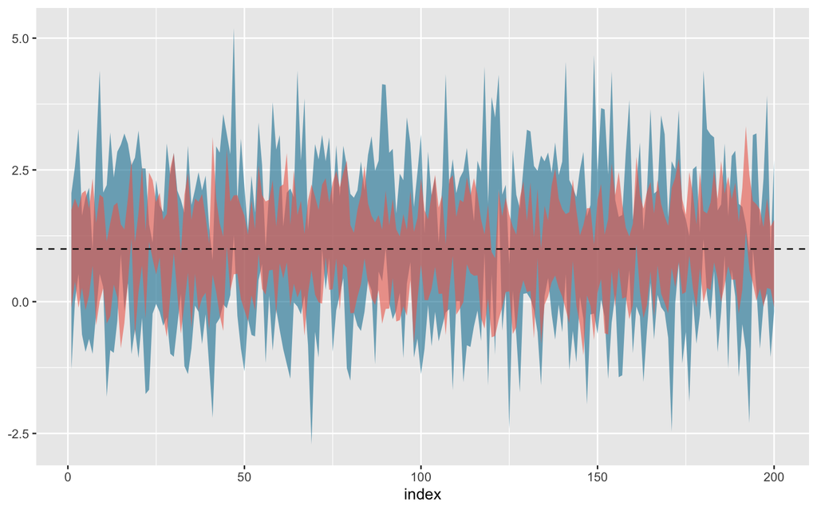

```r
# Evolución del ancho de los CIs
ggplot() +
  geom_ribbon(data = CI_in, aes(x = index, ymin = low, ymax = high), fill = "#1380A1", alpha = 0.6) +
  geom_ribbon(data = CI_in_50, aes(x = index, ymin = low, ymax = high), fill = "#ED6A5A", alpha = 0.6) +
  geom_hline(yintercept = 1, color = "black", linetype = "dashed")
```

## 4 - La interacción

Utilizando el dataset `cats` del paquete *{MASS}*, ajuste un modelo lineal para estimar el peso del corazón (en g) `Hwt` a partir de la variable continua peso del cuerpo (en Kg) `Bwt` y la variable discreta sexo `Sex`.

Vizualice los resultados e interprete la salida de `summary()` ¿Hay diferencia entre `summary()` y `Anova(. , type =3)`? ¿Por qué?

Escriba la ecuación y estime el peso del corazón para un gato **macho** de **3 Kg** y para una gata **hembra** de **2 Kg**.

Escribe el modelo lineal para gatos hembras y machos agrupando pendientes y ordenadas al origen ¿Para qué sexo la pendiente es más empinada?

```r
# install.packages("MASS")
library(MASS)

# Modelo gatos
model_cats <- cats %>% lm(Hwt ~ Bwt * Sex, .)
summary(model_cats)
```

```
#>
#> Call:
#> lm(formula = Hwt ~ Bwt * Sex, data = .)
#>
#> Residuals:
#>     Min      1Q  Median      3Q     Max
#> -3.7728 -1.0118 -0.1196  0.9272  4.8646
#>
#> Coefficients:
#>             Estimate Std. Error t value Pr(>|t|)
#> (Intercept)   2.9813     1.8428   1.618 0.107960
#> Bwt           2.6364     0.7759   3.398 0.000885 ***
#> SexM         -4.1654     2.0618  -2.020 0.045258 *
#> Bwt:SexM      1.6763     0.8373   2.002 0.047225 *
#> ---
#> Signif. codes:  0 '***' 0.001 '**' 0.01 '*' 0.05 '.' 0.1 ' ' 1
#>
#> Residual standard error: 1.442 on 140 degrees of freedom
#> Multiple R-squared:  0.6566, Adjusted R-squared:  0.6493
#> F-statistic: 89.24 on 3 and 140 DF,  p-value: < 2.2e-16
```

```r
Anova(model_cats, type = 3)
```

```
#> Anova Table (Type III tests)
#>
#> Response: Hwt
#>              Sum Sq  Df F value    Pr(>F)
#> (Intercept)   5.441   1  2.6172 0.1079605
#> Bwt          24.002   1 11.5455 0.0008846 ***
#> Sex           8.485   1  4.0817 0.0452578 *
#> Bwt:Sex       8.332   1  4.0077 0.0472246 *
#> Residuals   291.047 140
#> ---
#> Signif. codes:  0 '***' 0.001 '**' 0.01 '*' 0.05 '.' 0.1 ' ' 1
```

```r
# PesoCora = 2.9813 + 2.6364 * PesoTotal - 4.1654 * SexoM + 1.6763 * PesoTotal x SexoM
# Gato hembra:
# PesoCoraH = 2.9813 + 2.6364 * PesoTotal
# Gato macho:
# PesoCoraM = (2.9813 - 4.1654) + (2.6364 + 1.6763) * PesoTotal
```

## 5 - Muchas variables

Utilizando el dataset `birth14` del paquete *{openintro}*, ajuste un modelo lineal para estimar el peso de los recién nacidos (en libras) `weight` utilizando como regresores la longitud del embarazo en semanas `weeks`, la edad de la madre en años `mage`, el sexo del bebé `sex`, si la madre era fumadora `habit`, y el número de visitas al hospital durante el embarazo `visits`.

Escriba la ecuación del modelo completo.

Interprete las pendientes de `weeks` y `habit` en este contexo.

Calcule los residuos para el primer valor del dataset.

Estime el peso **en Kg** para un bebé *female* nacido después de **39 semanas** de embarazo, con una madre de **38 años** de edad, **fumadora** y con **12 visitas** al hospital durante el embarazo.

```r
# El modelo
library(openintro)

model_births <- births14 %>%
  drop_na() %>%
  lm(weight ~ weeks + mage + sex + habit + visits, .)

summary(model_births)
```

```
#>
#> Call:
#> lm(formula = weight ~ weeks + mage + sex + habit + visits, data = .)
#>
#> Residuals:
#>     Min      1Q  Median      3Q     Max
#> -3.4351 -0.6882  0.0084  0.7018  3.7021
#>
#> Coefficients:
#>              Estimate Std. Error t value Pr(>|t|)
#> (Intercept) -3.650658   0.631919  -5.777 1.09e-08 ***
#> weeks        0.263989   0.015514  17.017  < 2e-16 ***
#> mage         0.014886   0.006679   2.229  0.02612 *
#> sexmale      0.424400   0.074285   5.713 1.57e-08 ***
#> habitsmoker -0.449862   0.140693  -3.197  0.00144 **
#> visits       0.006442   0.009624   0.669  0.50346
#> ---
#> Signif. codes:  0 '***' 0.001 '**' 0.01 '*' 0.05 '.' 0.1 ' ' 1
#>
#> Residual standard error: 1.043 on 788 degrees of freedom
#> Multiple R-squared:  0.315,  Adjusted R-squared:  0.3106
#> F-statistic: 72.46 on 5 and 788 DF,  p-value: < 2.2e-16
```

```r
# Peso = -3.650658 + 0.263989 * weeks + 0.014886 * mage + 0.424400 * sexmale - 0.449862 habitsmoker + 0.006442 * visits

# Residuos
residuo <- abs(predict.lm(model_births, births14[1,]) - births14$weight[1])

# Predicciones
predict.lm(model_births, tibble(sex = "female", weeks = 39, mage = 38, habit = "smoker", visits = 12)) * 0.453592
```

```
#>        1
#> 3.101662
```